# TP 2 : Chaînage de points de contours

```python
import numpy as np
```

```python
!pip install opencv-python
```

```python
from skimage import filters
from skimage import data, io, morphology
from skimage.io import imread
import matplotlib.pyplot as plt
import numpy as np
import io
```

```python
def lever_exception(f):
    '''
    Notre fameuse fonction qui lève des exceptions
    '''
    raise Exception("Il y'a un problème au niveau de la fonction ",f)
```

#### 2.1) Génération d'une image binaire de synthèse

```python
image= np.zeros((16,16)) # On créé une matrice de taille 16x16 de valeurs 0

image[0][10]=1                   # On met à 1 les valeurs des pixels de contour
image[1][11]=1
image[2][3:6]=1
image[2][12]=1
image[3][2]=1
image[3][6]=1
image[3][13]=1
image[4][1]=1
image[4][6]=1
image[4][13]=1
image[5][1]=1
image[5][6]=1
image[5][13]=1
image[6][2]=1
image[6][6]=1
image[6][13:15]=1
image[7][3]=1
image[7][5]=1
image[7][6]=1
image[7][14]=1
image[8][4]=1
image[8][7]=1
image[7][14:15]=1
image[8][15]=1
image[8][14]=1
image[7][14]=1
image[9][8]=1
image[10][9]=1
image[11][12:16]=1
image[12][6:12]=1
image[13][3:7]=1
image[14][0:3]=1
```

```python
print(image)
```

```
[[0. 0. 0. 0. 0. 0. 0. 0. 0. 0. 1. 0. 0. 0. 0. 0.]
 [0. 0. 0. 0. 0. 0. 0. 0. 0. 0. 0. 1. 0. 0. 0. 0.]
 [0. 0. 0. 1. 1. 1. 0. 0. 0. 0. 0. 0. 1. 0. 0. 0.]
 [0. 0. 1. 0. 0. 0. 1. 0. 0. 0. 0. 0. 0. 1. 0. 0.]
 [0. 1. 0. 0. 0. 0. 1. 0. 0. 0. 0. 0. 0. 1. 0. 0.]
 [0. 1. 0. 0. 0. 0. 1. 0. 0. 0. 0. 0. 0. 1. 0. 0.]
 [0. 0. 1. 0. 0. 0. 1. 0. 0. 0. 0. 0. 0. 1. 1. 0.]
 [0. 0. 0. 1. 0. 1. 1. 0. 0. 0. 0. 0. 0. 0. 1. 0.]
 [0. 0. 0. 0. 1. 0. 0. 1. 0. 0. 0. 0. 0. 0. 1. 1.]
 [0. 0. 0. 0. 0. 0. 0. 0. 1. 0. 0. 0. 0. 0. 0. 0.]
 [0. 0. 0. 0. 0. 0. 0. 0. 0. 1. 0. 0. 0. 0. 0. 0.]
 [0. 0. 0. 0. 0. 0. 0. 0. 0. 0. 0. 0. 1. 1. 1. 1.]
 [0. 0. 0. 0. 0. 0. 1. 1. 1. 1. 1. 1. 0. 0. 0. 0.]
 [0. 0. 0. 1. 1. 1. 1. 0. 0. 0. 0. 0. 0. 0. 0. 0.]
 [1. 1. 1. 0. 0. 0. 0. 0. 0. 0. 0. 0. 0. 0. 0. 0.]
 [0. 0. 0. 0. 0. 0. 0. 0. 0. 0. 0. 0. 0. 0. 0. 0.]]
```

```python
type(image)
```

```
numpy.ndarray
```

```python
image.shape
```

```
(16, 16)
```

## a) l’image de synthèse générée

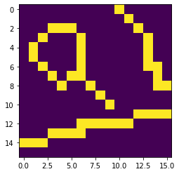

```python
plt.imshow(image)
```

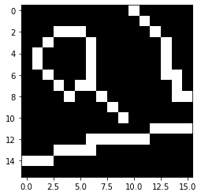

```python
plt.imshow(image, cmap="gray")
```

## Balayage vidéo (en intensité)

```python
def numerotation(img):
    '''
    Balayage Vidéo
    '''
    # récupération des dimensions
    dimx, dimy = img.shape
    # numérotation
    k = 0 #ici je commence par initialiser la variable qui fiat le décompte !
    for i in range(dimx):
        for j in range(dimy):
            if img[i,j]==1 :
                k += 1
                img[i,j] = k
    return img
```

```python
im_num = numerotation(image)
```

```python
print(im_num)
```

```
[[ 0.  0.  0.  0.  0.  0.  0.  0.  0.  0.  1.  0.  0.  0.  0.  0.]
 [ 0.  0.  0.  0.  0.  0.  0.  0.  0.  0.  0.  2.  0.  0.  0.  0.]
 [ 0.  0.  0.  3.  4.  5.  0.  0.  0.  0.  0.  0.  6.  0.  0.  0.]
 [ 0.  0.  7.  0.  0.  0.  8.  0.  0.  0.  0.  0.  0.  9.  0.  0.]
 [ 0. 10.  0.  0.  0.  0. 11.  0.  0.  0.  0.  0.  0. 12.  0.  0.]
 [ 0. 13.  0.  0.  0.  0. 14.  0.  0.  0.  0.  0.  0. 15.  0.  0.]
 [ 0.  0. 16.  0.  0.  0. 17.  0.  0.  0.  0.  0.  0. 18. 19.  0.]
 [ 0.  0.  0. 20.  0. 21. 22.  0.  0.  0.  0.  0.  0.  0. 23.  0.]
 [ 0.  0.  0.  0. 24.  0.  0. 25.  0.  0.  0.  0.  0.  0. 26. 27.]
 [ 0.  0.  0.  0.  0.  0.  0.  0. 28.  0.  0.  0.  0.  0.  0.  0.]
 [ 0.  0.  0.  0.  0.  0.  0.  0.  0. 29.  0.  0.  0.  0.  0.  0.]
 [ 0.  0.  0.  0.  0.  0.  0.  0.  0.  0.  0.  0. 30. 31. 32. 33.]
 [ 0.  0.  0.  0.  0.  0. 34. 35. 36. 37. 38. 39.  0.  0.  0.  0.]
 [ 0.  0.  0. 40. 41. 42. 43.  0.  0.  0.  0.  0.  0.  0.  0.  0.]
 [44. 45. 46.  0.  0.  0.  0.  0.  0.  0.  0.  0.  0.  0.  0.  0.]
 [ 0.  0.  0.  0.  0.  0.  0.  0.  0.  0.  0.  0.  0.  0.  0.  0.]]
```

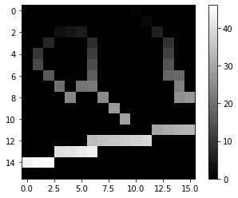

```python
plt.imshow(im_num, cmap="gray")
plt.colorbar()
```

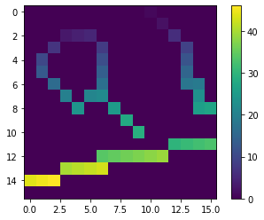

```python
plt.imshow(im_num)
plt.colorbar()
```

```python
im_num.shape
```

```
(16, 16)
```

## c) algorithme de chaînage de points de contours

```python
def get_past(image, i, j):
    '''
    Renvoie une liste contenant les coordonnées des voisins antérieur (passé)
    en 8-connexité !!!
    '''
    if i == 0 and j == 0:  # pixel dans le coin supérieur gauche
        return []
    gauche = [(i, j-1)] if image[i][j-1] else []  # voisin gauche
    if i == 0:  # pixel sur la rangée supérieure
        return gauche
    premiere_ligne = [(i-1, j_) for j_ in range(max(j-1, 0), min(j+2, image.shape[1])) if image[i-1, j_]]
    if j == 0:  # pixel sur la première colonne
        return premiere_ligne
    return premiere_ligne + gauche
```

### c.2) Algorithme

```python
def chainage_contour(img):
    '''
    Cette fonction fait du chaînage de points de contour
    en traitement parallèle, afin de afin de ressortir la liste des
    contours d'une image.
    '''
    im_num = numerotation(img) # récupération de la numérotation de chaque pixel

    chain = [] # initialisation de la liste chaine

    ident = np.zeros(img.shape).astype("int") # récupération des dimensions de l'image
    xdim,ydim = ident.shape

    # Partie parcours vidéo de l'image :
    for i in range(xdim):
        for j in range(ydim):
            voisins = get_past(img,i,j) # voisins is NB : on récupère les voisins d'un pixel
            p = int(img[i,j]) # p est un pixel_contour
            if not p : # si il n'a pas de contours alors on passe au suivant
                continue

            if len(voisins)==0:
                chain.append([(i,j)]) # p : la coordonnée (i,j)
                ident[i,j]=len(chain)
            else:
                identifiant = ident[voisins[0]]
                chain[identifiant-1].append((i,j))
                ident[i,j]=identifiant

                if(len(voisins)>1): # cas de fusions de contours
                    identifiants = [int(ident[v]) for v in voisins] # On récupère les contours(indices) , ex : [A,B,C]=[3,2,1]
                    identifiants.append(identifiant) # On a la liste des indices Chain = [[..],[..],[..]] id_x = [3,2]
                    id_min = min(identifiants) # on récupère l'id min de voisins : ex : id_min = 1
                    for id_i in identifiants:
                        if(id_i>id_min): # Si l'indice de id_min est plus grand que celle de l'indice principale
                            '''
                            Ci-dessous, LA LIGNE à MODIFIER !!!!!!
                            '''
                            #ident[i,j] = 1#ident[i,j] -= 1 # on réduit de 1
                            for point_p in chain[id_i-1]: #
                                ident[point_p] = id_min
                            chain[id_min-1].extend(chain[id_i-1])
                            chain.pop(id_i-1)
    return identifiant, chain, ident
```

```python
int(image[5,4])
```

```
0
```

```python
nb_id, chaine, newIMG = chainage_contour(image)
```

### Image résultante de la matrice ident

```python
newIMG
```

```
array([[0, 0, 0, 0, 0, 0, 0, 0, 0, 0, 1, 0, 0, 0, 0, 0],
       [0, 0, 0, 0, 0, 0, 0, 0, 0, 0, 0, 1, 0, 0, 0, 0],
       [0, 0, 0, 2, 2, 2, 0, 0, 0, 0, 0, 0, 1, 0, 0, 0],
       [0, 0, 2, 0, 0, 0, 2, 0, 0, 0, 0, 0, 0, 1, 0, 0],
       [0, 2, 0, 0, 0, 0, 2, 0, 0, 0, 0, 0, 0, 1, 0, 0],
       [0, 2, 0, 0, 0, 0, 2, 0, 0, 0, 0, 0, 0, 1, 0, 0],
       [0, 0, 2, 0, 0, 0, 2, 0, 0, 0, 0, 0, 0, 1, 1, 0],
       [0, 0, 0, 2, 0, 2, 2, 0, 0, 0, 0, 0, 0, 0, 1, 0],
       [0, 0, 0, 0, 2, 0, 0, 2, 0, 0, 0, 0, 0, 0, 1, 1],
       [0, 0, 0, 0, 0, 0, 0, 0, 2, 0, 0, 0, 0, 0, 0, 0],
       [0, 0, 0, 0, 0, 0, 0, 0, 0, 2, 0, 0, 0, 0, 0, 0],
       [0, 0, 0, 0, 0, 0, 0, 0, 0, 0, 0, 0, 3, 3, 3, 3],
       [0, 0, 0, 0, 0, 0, 3, 3, 3, 3, 3, 3, 0, 0, 0, 0],
       [0, 0, 0, 3, 3, 3, 3, 0, 0, 0, 0, 0, 0, 0, 0, 0],
       [3, 3, 3, 0, 0, 0, 0, 0, 0, 0, 0, 0, 0, 0, 0, 0],
       [0, 0, 0, 0, 0, 0, 0, 0, 0, 0, 0, 0, 0, 0, 0, 0]])
```

```python
nb_id
```

```
3
```

Le nombre de contours est 3

### La première liste chaînée et les autres

```python
print("La première liste chaînée :\n")
print("1 -> ",chaine[0])
```

```
La première liste chaînée :

1 ->  [(0, 10), (1, 11), (2, 12), (3, 13), (4, 13), (5, 13), (6, 13), (6, 14), (7, 14), (8, 14), (8, 15)]
```

En effet, la première liste chaînée a bel et bien été obtenue.

```python
for i in range(len(chaine)):
    print("-",i+1,"e liste chaînée :\n")
    print(i+1," -> ",chaine[i])
    print("\n")
```

```
- 1 e liste chaînée :

1  ->  [(0, 10), (1, 11), (2, 12), (3, 13), (4, 13), (5, 13), (6, 13), (6, 14), (7, 14), (8, 14), (8, 15)]


- 2 e liste chaînée :

2  ->  [(2, 3), (2, 4), (2, 5), (3, 2), (3, 6), (4, 1), (4, 6), (5, 1), (5, 6), (6, 2), (6, 6), (7, 3), (7, 5), (7, 6), (8, 4), (8, 7), (9, 8), (10, 9)]


- 3 e liste chaînée :

3  ->  [(11, 12), (11, 13), (11, 14), (11, 15), (12, 11), (12, 6), (12, 7), (12, 8), (12, 9), (12, 10), (13, 5), (13, 3), (13, 4), (13, 6), (14, 2), (14, 0), (14, 1)]
```

### b) la structure des contours (la liste chaînée de listes de points de contours) après avoir traité l’image avec l’algorithme parallèle proposé

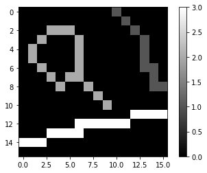

```python
plt.imshow(newIMG,cmap="gray")
plt.colorbar()
```

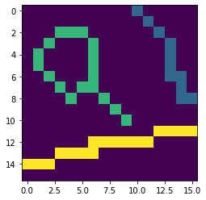

```python
plt.imshow(newIMG)
```

```python
import pandas as pd
```

```python
def color_df(cell_value):
    '''
    Cette focntion permet d'ajouter des couleurs
    dans un DataFrames avec Pandas.
    source1 : https://www.linkedin.com/feed/update/urn:li:activity:6905471955059699712/
    source2 : https://kanoki.org/2019/01/02/pandas-trick-for-the-day-color-code-columns-rows-cells-of-dataframe/
    '''
    txt = 'color:%s'
    if cell_value==1:
        return txt%'red'
    elif cell_value==2:
        return txt%'blue'
    elif cell_value==3:
        return txt%'orange'
    else :
        return txt%'black'
    return lever_exception(color_df)
```

```python
img_df = pd.DataFrame(newIMG)
img_df.style.applymap(color_df)
```

|  | 0 | 1 | 2 | 3 | 4 | 5 | 6 | 7 | 8 | 9 | 10 | 11 | 12 | 13 | 14 | 15 |
| --- | --- | --- | --- | --- | --- | --- | --- | --- | --- | --- | --- | --- | --- | --- | --- | --- |
| 0 | 0 | 0 | 0 | 0 | 0 | 0 | 0 | 0 | 0 | 0 | 1 | 0 | 0 | 0 | 0 | 0 |
| 1 | 0 | 0 | 0 | 0 | 0 | 0 | 0 | 0 | 0 | 0 | 0 | 1 | 0 | 0 | 0 | 0 |
| 2 | 0 | 0 | 0 | 2 | 2 | 2 | 0 | 0 | 0 | 0 | 0 | 0 | 1 | 0 | 0 | 0 |
| 3 | 0 | 0 | 2 | 0 | 0 | 0 | 2 | 0 | 0 | 0 | 0 | 0 | 0 | 1 | 0 | 0 |
| 4 | 0 | 2 | 0 | 0 | 0 | 0 | 2 | 0 | 0 | 0 | 0 | 0 | 0 | 1 | 0 | 0 |
| 5 | 0 | 2 | 0 | 0 | 0 | 0 | 2 | 0 | 0 | 0 | 0 | 0 | 0 | 1 | 0 | 0 |
| 6 | 0 | 0 | 2 | 0 | 0 | 0 | 2 | 0 | 0 | 0 | 0 | 0 | 0 | 1 | 1 | 0 |
| 7 | 0 | 0 | 0 | 2 | 0 | 2 | 2 | 0 | 0 | 0 | 0 | 0 | 0 | 0 | 1 | 0 |
| 8 | 0 | 0 | 0 | 0 | 2 | 0 | 0 | 2 | 0 | 0 | 0 | 0 | 0 | 0 | 1 | 1 |
| 9 | 0 | 0 | 0 | 0 | 0 | 0 | 0 | 0 | 2 | 0 | 0 | 0 | 0 | 0 | 0 | 0 |
| 10 | 0 | 0 | 0 | 0 | 0 | 0 | 0 | 0 | 0 | 2 | 0 | 0 | 0 | 0 | 0 | 0 |
| 11 | 0 | 0 | 0 | 0 | 0 | 0 | 0 | 0 | 0 | 0 | 0 | 0 | 3 | 3 | 3 | 3 |
| 12 | 0 | 0 | 0 | 0 | 0 | 0 | 3 | 3 | 3 | 3 | 3 | 3 | 0 | 0 | 0 | 0 |
| 13 | 0 | 0 | 0 | 3 | 3 | 3 | 3 | 0 | 0 | 0 | 0 | 0 | 0 | 0 | 0 | 0 |
| 14 | 3 | 3 | 3 | 0 | 0 | 0 | 0 | 0 | 0 | 0 | 0 | 0 | 0 | 0 | 0 | 0 |
| 15 | 0 | 0 | 0 | 0 | 0 | 0 | 0 | 0 | 0 | 0 | 0 | 0 | 0 | 0 | 0 | 0 |

## d) le code de Freeman

2 façon possible de le faire (voir : https://www.google.com/imgres?imgurl=https%3A%2F%2Fars.els-cdn.com%2Fcontent%2Fimage%2F1-s2.0-S1047320315000206-gr1.jpg&imgrefurl=https%3A%2F%2Fwww.sciencedirect.com%2Fscience%2Farticle%2Fpii%2FS1047320315000206&tbnid=Gd1V00OOEpccFM&vet=12ahUKEwjkiarYlNP2AhWRwoUKHS0-CmkQMyg9egQIARBY..i&docid=lBoWv3xpQMC_DM&w=579&h=296&q=code%20de%20freeman%20pixels&ved=2ahUKEwjkiarYlNP2AhWRwoUKHS0-CmkQMyg9egQIARBY)

1) en partant du principe que : considérant qu'un élément de contour relie 2 pixels connexes. source : http://carolinepetitjean.free.fr/enseignements/ti/c6freeman.pdf

```
Cela veut dire que pour le premier contour, le PIXEL(6,13) et le PIXEL(6,14) relie 2 chacun au total 3 pixel et donc ici on peut choisir de prendre l'un en laissant l'autre (inversement), pareille pour les pixel (7,5) et (7,6) du contour 2 et, (12,6) (12,7) (12,5) et (13,5) et (13,6) pour le contour 3 on aura alors selon cette configuration plusieurs possibilité par exemple pour le premier contour :
```

> contour 1.1 : 7 7 7 6 6 6 6 7 2 0

On omet donc le pixel(6,13)

> contour 1.2 : 7 7 7 6 6 6 7 2 2 0

On omet le pixel(6,14)

> Variante du 3 : 4 4 4 5 4 4 4 4 5 4 4 4 5 4 4

2) Mais intérressons-nous plutot à quelqu chose de plus générale et simple (sans philosopher) on a dans le respect des chaines de contours, le code suivant :

> code 1 : 7 7 7 6 6 6 6 0 2 2 0

> code 2 : 3 3 4 3 5 3 3 3 2 2 1 1 0 0 7 6 6 6 6 (il n'ya rien qui puisse nous empêcher de faire le parcours d'un sens comme dans un autre)

> code 3 : 4 4 4 5 4 4 4 4 4 6 4 4 4 5 4 4

### e ) Difficultés rencontrées :

Les 2 difficultés que j'ai rencontré sont les suivantes :

- Concernant l'algorithme de la question (2), la difficulté était principalement au nivreau de la fusion, mais le reste n'est que logique. (Voir annexe)
- Si on ne s'entient que, à ce que l'on a fait avec la prof en TD (façon générale) le code de freeman est simple à réaliser. Par ailleurs, si on prends pour reférence le cours, on doit trouver un compromis pour Freeman lorsqu'un pixel relie plus de 2 points et là on voit qu'il peut exister plusieurs altenrantives et pour cela il fallu que nous puissions entreprendre quelques recherches.

### f) Conclusion

Au terme de ce travail qui consistait à concillier théorie et pratique de notre cours de Computer Vision, le but était de :

1) Mettre en oeuvre l'algorithme du chaînage de contour tout en approchant le principe des listes chaînées

2) Réaliser le codage de freeman en 8-connexité sur une image

De facto nous avons su appréhender ces notions et en ressortons moins bête 😎 !!!

# ANNEXE !!!

## MA NOUVELLE IMAGE

```python
image= np.zeros((16,16)) # On créé une matrice de taille 16x16 de valeurs 0

image[0][10]=1                   # On met à 1 les valeurs des pixels de contour
image[1][11]=1
image[2][3:6]=1
image[2][12]=1
image[3][2]=1
image[3][6]=1
image[3][13]=1
image[4][1]=1
image[4][6]=1
image[4][13]=1
image[5][1]=1
image[5][4]=1
image[6][5]=1
image[5][6]=1
image[5][13]=1
image[6][2]=1
image[6][6]=1
image[6][13:15]=1
image[7][3]=1
image[7][5]=1
image[7][6]=1
image[7][14]=1
image[8][4]=1
image[8][7]=1
image[7][14:15]=1
image[8][15]=1
image[8][14]=1
image[7][14]=1
image[9][8]=1
image[10][9]=1
image[11][12:16]=1
image[12][6:12]=1
image[13][3:7]=1
image[14][0:3]=1
```

## ET DONC QUAND J'AI une NOUVELLE IMAGE J'ai UN problème !!!

```python
print(image)
```

```
[[0. 0. 0. 0. 0. 0. 0. 0. 0. 0. 1. 0. 0. 0. 0. 0.]
 [0. 0. 0. 0. 0. 0. 0. 0. 0. 0. 0. 1. 0. 0. 0. 0.]
 [0. 0. 0. 1. 1. 1. 0. 0. 0. 0. 0. 0. 1. 0. 0. 0.]
 [0. 0. 1. 0. 0. 0. 1. 0. 0. 0. 0. 0. 0. 1. 0. 0.]
 [0. 1. 0. 0. 0. 0. 1. 0. 0. 0. 0. 0. 0. 1. 0. 0.]
 [0. 1. 0. 0. 1. 0. 1. 0. 0. 0. 0. 0. 0. 1. 0. 0.]
 [0. 0. 1. 0. 0. 1. 1. 0. 0. 0. 0. 0. 0. 1. 1. 0.]
 [0. 0. 0. 1. 0. 1. 1. 0. 0. 0. 0. 0. 0. 0. 1. 0.]
 [0. 0. 0. 0. 1. 0. 0. 1. 0. 0. 0. 0. 0. 0. 1. 1.]
 [0. 0. 0. 0. 0. 0. 0. 0. 1. 0. 0. 0. 0. 0. 0. 0.]
 [0. 0. 0. 0. 0. 0. 0. 0. 0. 1. 0. 0. 0. 0. 0. 0.]
 [0. 0. 0. 0. 0. 0. 0. 0. 0. 0. 0. 0. 1. 1. 1. 1.]
 [0. 0. 0. 0. 0. 0. 1. 1. 1. 1. 1. 1. 0. 0. 0. 0.]
 [0. 0. 0. 1. 1. 1. 1. 0. 0. 0. 0. 0. 0. 0. 0. 0.]
 [1. 1. 1. 0. 0. 0. 0. 0. 0. 0. 0. 0. 0. 0. 0. 0.]
 [0. 0. 0. 0. 0. 0. 0. 0. 0. 0. 0. 0. 0. 0. 0. 0.]]
```

```python
nb_id, chaine, newIMG = chainage_contour(image)
```

```
---------------------------------------------------------------------------
IndexError                                Traceback (most recent call last)
<ipython-input-214-ecd6029292c8> in <module>
----> 1 nb_id, chaine, newIMG = chainage_contour(image)

<ipython-input-196-877048395420> in chainage_contour(img)
     38                             '''
     39                             #ident[i,j] = 1#ident[i,j] -= 1 # on réduit de 1
---> 40                             for point_p in chain[id_i-1]: #
     41                                 ident[point_p] = id_min
     42                             chain[id_min-1].extend(chain[id_i-1])

IndexError: list index out of range
```

```python
def chainage_contour2(img):
    '''
    Cette fonction fait du chaînage de points de contour
    en traitement parallèle, afin de afin de ressortir la liste des
    contours d'une image.
    '''
    im_num = numerotation(img) # récupération de la numérotation de chaque pixel

    chain = [] # initialisation de la liste chaine

    ident = np.zeros(img.shape).astype("int") # récupération des dimensions de l'image
    xdim,ydim = ident.shape

    # Partie parcours vidéo de l'image :
    for i in range(xdim):
        for j in range(ydim):
            voisins = get_past(img,i,j) # voisins is NB : on récupère les voisins d'un pixel
            p = int(img[i,j]) # p est un pixel_contour
            if not p : # si il n'a pas de contours alors on passe au suivant
                continue

            if len(voisins)==0:
                chain.append([(i,j)]) # p : la coordonnée (i,j)
                ident[i,j]=len(chain)
            else:
                identifiant = ident[voisins[0]]
                chain[identifiant-1].append((i,j))
                ident[i,j]=identifiant

                if(len(voisins)>1): # cas de fusions de contours
                    identifiants = [int(ident[v]) for v in voisins] # On récupère les contours(indices) , ex : [A,B,C]=[3,2,1]
                    identifiants.append(identifiant) # On a la liste des indices Chain = [[..],[..],[..]] id_x = [3,2]
                    id_min = min(identifiants) # on récupère l'id min de voisins : ex : id_min = 1
                    for id_i in identifiants:
                        if(id_i>id_min): # Si l'indice de id_min est plus grand que celle de l'indice principale
                            for point_p in chain[id_i-1]: #
                                ident[point_p] = id_min
                            '''
                            Ci-dessous, LA LIGNE à MODIFIER !!!!!!
                            '''
                            ident[i,j] = 1#ident[i,j] -= 1 # on réduit de 1
                            #for c in chain[id_i:]:
                                #for p in c:
                                    #idenpoint_ppppppppppt_pt_p0]+1,p[1]+1] += 1 # -= 1

                            chain[id_min-1].extend(chain[id_i-1])
                            chain.pop(id_i-1)

    return identifiant, chain, ident
```

```python
nb_id, chaine, newIMG = chainage_contour2(image)
```

[output not shown]